# Does College Free Throw Percentage Really Correalte to NBA Three Point Percentage?

## Exploring how college percentages relate to NBA numbers from the last decade

## Final Project by Trevor Tabit and Serena Tong

# Introduction

In this project we will provide the reader with a tutorial on both what linear regression is and how it can be applied to datasets in python. The topics covered include linear regression, data visualation, data collection, data management, and data analysis. To accomplish this we will be looking at data from NBA players careers in both the NBA and College to answer our overarching question.

# Our Question:

Not everyone is an NBA or College basketball fan, but a data scientist should be fan of the massive amounts of data availbe in both sectors that can be analyzied. This large amount of data gives us data scientists to test many of the common statements that those around the game of basketball make. As college and NBA basketball fans ourselves we often hear commentators and reporters making claims about how young players will develop with nothing to back it up. One of these claims that has long been floating around the basketball world is "he shoots well on his free throws in college so he will probably develop into a good NBA three point shooter". If you watch a game of college basketball or the NBA draft you'll often hear this said about prospects and young players in the NBA. However, as data scientists we were always left wondering, is this claim really true? A free throw is a vastly different shot from a three pointer. The free throw is taken closer to the basket and without defenders actively guarding the player. The three pointer is taken in the middle of a play with many different variables impacting the shot like defenders, quality of the pass, if the player is moving or set, and many others. So we set out to test this claim by compiling both NBA and college basketball stats for every player who has been drafted in the last 10 years.

The reason the question we have proposed is of useful significance is twofold. One: it pertains to the casual audience. With such a big market and fanbase that surrounds March Madness and the NBA, there is a lot of room for fans to grow attachments and follow the careers of select players from college to the professional league. This question allows fans to predict whether or not their favorite players will perform well past college. Basketball players growing up, whether recreational or professionally-motivated, can learn the measures of a good basketball player in the NBA and which college statistics are real indicators. This can give an aspiring player faith that even if a certain skill isn’t their strongest right now, success in a different area might foretell success in the area they're struggling with down the line.

For our dataset we use linear regression to determine whether or not shooting percentage success in college basketball indicates success shooting three pointers over a career in the NBA. Later in this tutorial we will perform three different linear regressions to find whether college field goal percentage, college three point percentage, or college free throw percentage is the most impactful variable on NBA three point percentage.

# What is Linear Regression?

Data science uses scientific and technological processes in order to extract knowledge and insight from data and apply it elsewhere. Linear regression could be argued to be the epitome of data science, and it is one of the most common algorithms that data scientists use which is why we have chosen it as our approach in analyzing our dataset.

Linear regression is a machine learning model that relies on an independent and dependent variable in order to predict a line of best fit and determine the most optimal values of intercept and coeffecients. The goal is to minimize error as much as possible. A multiple linear regression involves multiple independent variables for the model to find a relationship with. In our data set, we have multiple independent variables (3-point percentage, field goal percentage, college vs the NBA, etc.) which are used to analyze our dependent variable: three-point percentage in the NBA.

The benefits and importance of linear regression is that it is a prediction model, meaning that it can help businesses and individuals observe past or current patterns or predict future trends in order to benefit themselves or improve their current practices or strategies. Linear regression notes which independent variables have the most effect on the dependent variable, and helps determine which factors should be emphasized or overlooked.

In this tutorial we will be looking at regression coefficients between the big three statistics of both college and NBA basketball. A more formal definition of regression coefficients states that a positive coefficient indicates a positive relationship between the independent and dependent variable meaning that an increasing independent variable indicates an increasing dependent variable. Conversely, a negative coefficient indicates a negative correlation wherein an increasing independent variable indicates a decreasing dependent variable.

# Imports needed:

The libraries below are used throughout the project to help visualize and analyze our data. This tutorial will not go into depth on all that these libraries can provide and do. Instead it will focus on a more indepth review of the specific methods found within each library that are relevant to answering our overarching question. To learn more about each of the libraries below and all they can do a simple google search with the library name will bring up the documentation. From there you'll be able to explore the library and get a good sense of all it can do.

```python
import numpy as np
import matplotlib.pyplot as plt
from sklearn.linear_model import LinearRegression
from sklearn.model_selection import train_test_split
import seaborn as sb
import pandas as pd
from IPython.display import display, HTML
```

# Our First Dataset

For this project we need two sets of data. One should be our player's stats from their NBA careers and the other should be a player's stats from their college careers. The first data set that we import into our notebook is the NBA statistics dataset. The dataset we are using for this project can be found at the link: https://www.kaggle.com/datasets/benwieland/nba-draft-data?resource=download. To use this dataset, all one needs to do is click the download button at the top right of the page that appears when clicking the link. After that a zip file should download containing the csv with our data. Additionally, this data can be found on my github using this link: https://github.com/trevmt1/trevmt1.github.io. In this tutorial we will be reading in the data using raw.githubusercontent which allows us to get a raw csv hosted on the github.

In this first line of our code below we use the pandas library we imported above to read the csv we downloaded and store it as a data frame. After that we need to make some modifications to our data set to make it both easier to use and easier to read. The first thing we do is drop columns that we won't be using for this tutorial. It's usually good practice to drop any unused columns from a data frame to make operation on your data frame faster and increase readability. The next step we take is removing all players who were drafted before 2011 as the goal of our analysis is to look at trends in the last decade. Finally, we rename the columns of our data frame to make it easier to work with and reset the index. The data frame we're going to work with can be seen below showing the first 20 entries.

```python
#read in our csv what we downloaded from Kaggle page
data_nba = pd.read_csv("https://raw.githubusercontent.com/trevmt1/trevmt1.github.io/main/draft-data-20-years.csv", sep=',')
#drop columns that we won't be using and remove players before 2011
data_nba.drop(['Unnamed: 0','Tm','playerurl', 'VORP', 'BPM', 'Rk', 'Pk', 'DraftYr'], axis=1, inplace=True)
data_nba = data_nba[~(data_nba['DraftYear'] < 2011)]
#rename columns to make them easier to work with
data_nba = data_nba.rename(columns={'Player':'player_name','Yrs':'nba_yrs','G':'nba_games','TOTMP':'nba_min','TOTPTS':'nba_pts','TOTTRB':'nba_rb','TOTAST':'nba_ast',
                                    'FG%':'nba_FG%','3P%':'nba_3P%','FT%':'nba_ft%','WS':'nba_ws','WS/48':'nba_ws48', 'MPG':'nba_mpg','PPG':'nba_PPG','RPG':'nba_RPG','APG':'nba_APG'})
data_nba = data_nba.reset_index()
display(HTML(data_nba.head(20).to_html()))
```

|  | index | player_name | College | nba_yrs | nba_games | nba_min | nba_pts | nba_rb | nba_ast | nba_FG% | nba_3P% | nba_ft% | nba_ws | nba_ws48 | nba_mpg | nba_PPG | nba_RPG | nba_APG | DraftYear |
| --- | --- | --- | --- | --- | --- | --- | --- | --- | --- | --- | --- | --- | --- | --- | --- | --- | --- | --- | --- |
| 0 | 1208 | Kyrie Irving | Duke | 11.0 | 596.0 | 20220.0 | 13631.0 | 2279.0 | 3411.0 | 0.469 | 0.391 | 0.882 | 69.8 | 0.166 | 33.9 | 22.9 | 3.8 | 5.7 | 2011 |
| 1 | 1209 | Derrick Williams | Arizona | 7.0 | 428.0 | 8864.0 | 3809.0 | 1693.0 | 293.0 | 0.434 | 0.300 | 0.710 | 14.1 | 0.076 | 20.7 | 8.9 | 4.0 | 0.7 | 2011 |
| 2 | 1210 | Enes Freedom | NaN | 11.0 | 748.0 | 16101.0 | 8349.0 | 5822.0 | 638.0 | 0.548 | 0.289 | 0.777 | 52.8 | 0.157 | 21.5 | 11.2 | 7.8 | 0.9 | 2011 |
| 3 | 1211 | Tristan Thompson | Texas | 11.0 | 707.0 | 19180.0 | 6462.0 | 6011.0 | 711.0 | 0.518 | 0.278 | 0.606 | 46.6 | 0.117 | 27.1 | 9.1 | 8.5 | 1.0 | 2011 |
| 4 | 1212 | Jonas Valančiūnas | NaN | 10.0 | 674.0 | 17559.0 | 8958.0 | 6338.0 | 771.0 | 0.563 | 0.366 | 0.784 | 65.4 | 0.179 | 26.1 | 13.3 | 9.4 | 1.1 | 2011 |
| 5 | 1213 | Jan Veselý | NaN | 3.0 | 162.0 | 2455.0 | 590.0 | 562.0 | 96.0 | 0.521 | 0.000 | 0.408 | 4.0 | 0.078 | 15.2 | 3.6 | 3.5 | 0.6 | 2011 |
| 6 | 1214 | Bismack Biyombo | NaN | 11.0 | 719.0 | 14521.0 | 3749.0 | 4423.0 | 433.0 | 0.530 | 0.000 | 0.565 | 29.0 | 0.096 | 20.2 | 5.2 | 6.2 | 0.6 | 2011 |
| 7 | 1215 | Brandon Knight | Kentucky | 9.0 | 449.0 | 13191.0 | 6299.0 | 1384.0 | 1777.0 | 0.411 | 0.353 | 0.807 | 11.7 | 0.043 | 29.4 | 14.0 | 3.1 | 4.0 | 2011 |
| 8 | 1216 | Kemba Walker | UConn | 11.0 | 741.0 | 24666.0 | 14414.0 | 2815.0 | 3919.0 | 0.418 | 0.360 | 0.840 | 59.5 | 0.116 | 33.3 | 19.5 | 3.8 | 5.3 | 2011 |
| 9 | 1217 | Jimmer Fredette | BYU | 6.0 | 241.0 | 3213.0 | 1438.0 | 243.0 | 331.0 | 0.409 | 0.372 | 0.879 | 2.2 | 0.033 | 13.3 | 6.0 | 1.0 | 1.4 | 2011 |
| 10 | 1218 | Klay Thompson | Washington State | 9.0 | 631.0 | 20744.0 | 12268.0 | 2190.0 | 1465.0 | 0.458 | 0.418 | 0.849 | 47.8 | 0.110 | 32.9 | 19.4 | 3.5 | 2.3 | 2011 |
| 11 | 1219 | Alec Burks | Colorado | 11.0 | 602.0 | 13605.0 | 6339.0 | 2068.0 | 1179.0 | 0.418 | 0.375 | 0.799 | 23.9 | 0.084 | 22.6 | 10.5 | 3.4 | 2.0 | 2011 |
| 12 | 1220 | Markieff Morris | Kansas | 11.0 | 708.0 | 17613.0 | 7770.0 | 3697.0 | 1144.0 | 0.446 | 0.341 | 0.777 | 27.0 | 0.073 | 24.9 | 11.0 | 5.2 | 1.6 | 2011 |
| 13 | 1221 | Marcus Morris | Kansas | 11.0 | 700.0 | 18965.0 | 8674.0 | 3232.0 | 1050.0 | 0.436 | 0.379 | 0.768 | 35.9 | 0.091 | 27.1 | 12.4 | 4.6 | 1.5 | 2011 |
| 14 | 1222 | Kawhi Leonard | San Diego State | 10.0 | 576.0 | 18025.0 | 11085.0 | 3689.0 | 1672.0 | 0.493 | 0.384 | 0.858 | 83.3 | 0.222 | 31.3 | 19.2 | 6.4 | 2.9 | 2011 |
| 15 | 1223 | Nikola Vučević | USC | 11.0 | 720.0 | 22214.0 | 12210.0 | 7536.0 | 1990.0 | 0.494 | 0.351 | 0.756 | 58.5 | 0.126 | 30.9 | 17.0 | 10.5 | 2.8 | 2011 |
| 16 | 1224 | Iman Shumpert | Georgia Tech | 10.0 | 461.0 | 11470.0 | 3320.0 | 1534.0 | 845.0 | 0.391 | 0.337 | 0.764 | 12.9 | 0.054 | 24.9 | 7.2 | 3.3 | 1.8 | 2011 |
| 17 | 1225 | Chris Singleton | Florida State | 3.0 | 148.0 | 2605.0 | 612.0 | 472.0 | 92.0 | 0.376 | 0.319 | 0.633 | 2.3 | 0.042 | 17.6 | 4.1 | 3.2 | 0.6 | 2011 |
| 18 | 1226 | Tobias Harris | Tennessee | 11.0 | 729.0 | 22807.0 | 11970.0 | 4523.0 | 1655.0 | 0.476 | 0.366 | 0.829 | 56.9 | 0.120 | 31.3 | 16.4 | 6.2 | 2.3 | 2011 |
| 19 | 1227 | Donatas Motiejūnas | NaN | 6.0 | 251.0 | 4566.0 | 1832.0 | 952.0 | 269.0 | 0.469 | 0.300 | 0.597 | 7.1 | 0.075 | 18.2 | 7.3 | 3.8 | 1.1 | 2011 |

# Our Second Dataset

For our second dataset we follow the same steps as the previous one. The one minor change is we delete any college player that wasn't drafted. Other than that the steps are the same where we delete unneeded columns and rename the remaining columns to make them easier to use.

```python
#read in our csv what we downloaded from Kaggle page
data_college = pd.read_csv("https://raw.githubusercontent.com/trevmt1/trevmt1.github.io/main/CollegeBasketballPlayers2009-2021.csv", sep=',', low_memory=False)
#drop columns that we won't be using and remove players before 2011
data_college.drop(['Unnamed: 64','Unnamed: 65','ast','stl','pts','AST_per','dbpm','mp','treb','ast/tov','ogbpm','dgbpm','oreb',
                   'dreb','blk','yr','twoP_per','ftr','porpag','Min_per','usg','conf','Ortg','eFG','TS_per','ORB_per','DRB_per','TO_per',
                   'blk_per','stl_per','ht','num','adjoe','pfr','pid','type','Rec Rank','rimmade','rimmade+rimmiss','midmade','midmade+midmiss',
                   'rimmade/(rimmade+rimmiss)','midmade/(midmade+midmiss)', 'dunksmade','dunksmiss+dunksmade', 'dunksmade/(dunksmade+dunksmiss)',
                   'drtg','adrtg','dporpag','stops','bpm','obpm','gbpm'], axis=1, inplace=True)
data_college = data_college[~(data_college['year'] < 2011)]
#remove any player not picked in the draft
data_college = data_college.dropna(subset=['pick'])
#rename columns to make them easier to work with
data_college = data_college.rename(columns={'team':'college_team','GP':'college_GP','FTM':'College_FTM','FTA':'college_FTA','FT_per':'college_FT%','twoPM':'college_2PM',
                                           'twoPA':'college_2PA','TPM':'college_3PM','TPA':'college_3PA','TP_per':'college_3P%','year':'college_year'})
data_college = data_college.reset_index()
display(HTML(data_college.head(20).to_html()))
```

|  | index | player_name | college_team | college_GP | College_FTM | college_FTA | college_FT% | college_2PM | college_2PA | college_3PM | college_3PA | college_3P% | college_year | pick |
| --- | --- | --- | --- | --- | --- | --- | --- | --- | --- | --- | --- | --- | --- | --- |
| 0 | 9291 | Charles Jenkins | Hofstra | 32 | 179 | 217 | 0.825 | 176 | 317 | 63 | 152 | 0.414 | 2011 | 44.0 |
| 1 | 9294 | Vernon Macklin | Florida | 37 | 46 | 102 | 0.451 | 191 | 322 | 0 | 0 | 0.000 | 2011 | 52.0 |
| 2 | 9312 | Kyle Singler | Duke | 37 | 125 | 155 | 0.806 | 157 | 316 | 62 | 193 | 0.321 | 2011 | 33.0 |
| 3 | 9313 | Nolan Smith | Duke | 37 | 187 | 230 | 0.813 | 203 | 405 | 57 | 163 | 0.350 | 2011 | 21.0 |
| 4 | 9314 | E'Twaun Moore | Purdue | 34 | 100 | 141 | 0.709 | 151 | 319 | 70 | 175 | 0.400 | 2011 | 55.0 |
| 5 | 9315 | JaJuan Johnson | Purdue | 34 | 169 | 209 | 0.809 | 242 | 469 | 15 | 51 | 0.294 | 2011 | 27.0 |
| 6 | 9459 | Lavoy Allen | Temple | 33 | 69 | 99 | 0.697 | 149 | 304 | 5 | 17 | 0.294 | 2011 | 50.0 |
| 7 | 9544 | Kenneth Faried | Morehead St. | 32 | 136 | 235 | 0.579 | 208 | 341 | 0 | 0 | 0.000 | 2011 | 22.0 |
| 8 | 9592 | Jon Diebler | Ohio St. | 37 | 64 | 79 | 0.810 | 31 | 59 | 114 | 227 | 0.502 | 2011 | 51.0 |
| 9 | 9595 | Jon Leuer | Wisconsin | 34 | 113 | 134 | 0.843 | 173 | 337 | 54 | 146 | 0.370 | 2011 | 40.0 |
| 10 | 9640 | Chandler Parsons | Florida | 36 | 54 | 97 | 0.557 | 112 | 206 | 43 | 117 | 0.368 | 2011 | 38.0 |
| 11 | 9708 | Robert Sacre | Gonzaga | 34 | 156 | 189 | 0.825 | 135 | 274 | 0 | 1 | 0.000 | 2011 | 60.0 |
| 12 | 9709 | Keith Benson | Oakland | 34 | 150 | 236 | 0.636 | 217 | 391 | 8 | 22 | 0.364 | 2011 | 48.0 |
| 13 | 9767 | Justin Harper | Richmond | 37 | 94 | 118 | 0.797 | 168 | 287 | 77 | 172 | 0.448 | 2011 | 32.0 |
| 14 | 9779 | Andrew Goudelock | College of Charleston | 37 | 110 | 134 | 0.821 | 187 | 377 | 131 | 322 | 0.407 | 2011 | 46.0 |
| 15 | 9783 | Jimmer Fredette | BYU | 36 | 250 | 280 | 0.893 | 221 | 450 | 121 | 308 | 0.393 | 2011 | 10.0 |
| 16 | 9941 | Mike Scott | Virginia | 10 | 52 | 59 | 0.881 | 52 | 109 | 1 | 1 | 1.000 | 2011 | 43.0 |
| 17 | 9955 | Norris Cole | Cleveland St. | 34 | 221 | 259 | 0.853 | 189 | 407 | 46 | 142 | 0.324 | 2011 | 28.0 |
| 18 | 9958 | Festus Ezeli | Vanderbilt | 34 | 140 | 216 | 0.648 | 151 | 257 | 0 | 0 | 0.000 | 2011 | 30.0 |
| 19 | 9972 | Markieff Morris | Kansas | 38 | 103 | 153 | 0.673 | 170 | 272 | 25 | 59 | 0.424 | 2011 | 13.0 |

# Combining our two Datasets

The next order of business is combining our two data sets into one data set containing all of the information that we need. The first thing we do is an inner merge of our data sets of players' names. However, just merging isn't enough as our college data is separated by year. This means for each year a player played in college they have their own row for that year. To fix this we iterate through our array and find all rows with matching player names. This allows us to create a new data frame for that player that contains either the average or the sum of their stats across all college years. Additionally we need to create our own 'college_FG%' using the formula: (data_college['twoPM'] + data_college['TPM']) / (data_college['twoPA'] + data_college['TPA']). This formula adds up total college makes and then divides it by total college attempts. After we do this we have one more step until we are finally done setting up our data and ready to work with it.

```python
#Since our college players data is seperated by year we need to go player by player and get their college career avgs by taking the mean of thier stats for all years
all_data = data_nba.merge(data_college, on = ['player_name'])
all_data
player = []
total_data = pd.DataFrame({})
for idx, rw in all_data.iterrows():
    if not (rw['player_name'] in player):
        player.append(rw['player_name'])
        df_player = all_data.loc[all_data['player_name'] == rw['player_name']]
        #create a data frame contianing this players averaged stats
        df_player = pd.DataFrame({
            'player_name' : [df_player['player_name'].iloc[0]],
            'nba_yrs' : [df_player['nba_yrs'].iloc[0]],
            'nba_games' : [df_player['nba_games'].iloc[0]],
            'nba_min' : [df_player['nba_min'].iloc[0]],
            'nba_pts' : [df_player['nba_pts'].iloc[0]],
            'nba_rb' : [df_player['nba_rb'].iloc[0]],
            'nba_ast' : [df_player['nba_ast'].iloc[0]],
            'nba_FG%' : [df_player['nba_FG%'].iloc[0]],
            'nba_3P%' : [df_player['nba_3P%'].iloc[0]],
            'nba_FT%' : [df_player['nba_ft%'].iloc[0]],
            'nba_ws' : [df_player['nba_ws'].iloc[0]],
            'nba_ws48' : [df_player['nba_ws48'].iloc[0]],
            'nba_mpg' : [df_player['nba_mpg'].iloc[0]],
            'nba_PPG' : [df_player['nba_PPG'].iloc[0]],
            'nba_RPG' : [df_player['nba_RPG'].iloc[0]],
            'nba_APG' : [df_player['nba_APG'].iloc[0]],
            'DraftYear' : [df_player['DraftYear'].iloc[0]],
            'college_team' : [df_player['college_team'].iloc[0]],
            'college_GP' : [df_player['college_GP'].sum()],
            'college_FTM' : [df_player['College_FTM'].sum()],
            'college_FTA' : [df_player['college_FTA'].sum()],
            'college_FT%' : [df_player['college_FT%'].mean()],
            'college_2PM' : [df_player['college_2PM'].sum()],
            'college_2PA' : [df_player['college_2PA'].sum()],
            'college_3PM' : [df_player['college_3PM'].sum()],
            'college_3PA' : [df_player['college_3PA'].sum()],
            'college_3P%' : [df_player['college_3P%'].mean()],
            'college_FG%' : [(df_player['college_2PM'].sum()+df_player['college_3PM'].sum())/(df_player['college_2PA'].sum()+df_player['college_3PA'].sum())],
            'pick' : [df_player['pick'].iloc[0]]
         })
        #add our new player data frame to the new total data frame we are making
        total_data = pd.concat([total_data,df_player], ignore_index = True)
display(HTML(total_data.head(20).to_html()))
```

|  | player_name | nba_yrs | nba_games | nba_min | nba_pts | nba_rb | nba_ast | nba_FG% | nba_3P% | nba_FT% | nba_ws | nba_ws48 | nba_mpg | nba_PPG | nba_RPG | nba_APG | DraftYear | college_team | college_GP | college_FTM | college_FTA | college_FT% | college_2PM | college_2PA | college_3PM | college_3PA | college_3P% | college_FG% | pick |
| --- | --- | --- | --- | --- | --- | --- | --- | --- | --- | --- | --- | --- | --- | --- | --- | --- | --- | --- | --- | --- | --- | --- | --- | --- | --- | --- | --- | --- | --- |
| 0 | Kyrie Irving | 11.0 | 596.0 | 20220.0 | 13631.0 | 2279.0 | 3411.0 | 0.469 | 0.391 | 0.882 | 69.8 | 0.166 | 33.9 | 22.9 | 3.8 | 5.7 | 2011 | Duke | 11 | 64 | 71 | 0.901 | 37 | 65 | 18 | 39 | 0.462 | 0.528846 | 1.0 |
| 1 | Derrick Williams | 7.0 | 428.0 | 8864.0 | 3809.0 | 1693.0 | 293.0 | 0.434 | 0.300 | 0.710 | 14.1 | 0.076 | 20.7 | 8.9 | 4.0 | 0.7 | 2011 | Arizona | 38 | 247 | 331 | 0.746 | 184 | 306 | 42 | 74 | 0.568 | 0.594737 | 2.0 |
| 2 | Tristan Thompson | 11.0 | 707.0 | 19180.0 | 6462.0 | 6011.0 | 711.0 | 0.518 | 0.278 | 0.606 | 46.6 | 0.117 | 27.1 | 9.1 | 8.5 | 1.0 | 2011 | Texas | 36 | 127 | 261 | 0.487 | 172 | 315 | 0 | 0 | 0.000 | 0.546032 | 4.0 |
| 3 | Brandon Knight | 9.0 | 449.0 | 13191.0 | 6299.0 | 1384.0 | 1777.0 | 0.411 | 0.353 | 0.807 | 11.7 | 0.043 | 29.4 | 14.0 | 3.1 | 4.0 | 2011 | Kentucky | 38 | 136 | 171 | 0.795 | 130 | 282 | 87 | 231 | 0.377 | 0.423002 | 8.0 |
| 4 | Kemba Walker | 11.0 | 741.0 | 24666.0 | 14414.0 | 2815.0 | 3919.0 | 0.418 | 0.360 | 0.840 | 59.5 | 0.116 | 33.3 | 19.5 | 3.8 | 5.3 | 2011 | Connecticut | 41 | 258 | 315 | 0.819 | 241 | 512 | 75 | 227 | 0.330 | 0.427605 | 9.0 |
| 5 | Jimmer Fredette | 6.0 | 241.0 | 3213.0 | 1438.0 | 243.0 | 331.0 | 0.409 | 0.372 | 0.879 | 2.2 | 0.033 | 13.3 | 6.0 | 1.0 | 1.4 | 2011 | BYU | 36 | 250 | 280 | 0.893 | 221 | 450 | 121 | 308 | 0.393 | 0.451187 | 10.0 |
| 6 | Klay Thompson | 9.0 | 631.0 | 20744.0 | 12268.0 | 2190.0 | 1465.0 | 0.458 | 0.418 | 0.849 | 47.8 | 0.110 | 32.9 | 19.4 | 3.5 | 2.3 | 2011 | Washington St. | 34 | 155 | 185 | 0.838 | 142 | 305 | 98 | 246 | 0.398 | 0.435572 | 11.0 |
| 7 | Alec Burks | 11.0 | 602.0 | 13605.0 | 6339.0 | 2068.0 | 1179.0 | 0.418 | 0.375 | 0.799 | 23.9 | 0.084 | 22.6 | 10.5 | 3.4 | 2.0 | 2011 | Colorado | 37 | 245 | 298 | 0.822 | 215 | 421 | 28 | 95 | 0.295 | 0.470930 | 12.0 |
| 8 | Markieff Morris | 11.0 | 708.0 | 17613.0 | 7770.0 | 3697.0 | 1144.0 | 0.446 | 0.341 | 0.777 | 27.0 | 0.073 | 24.9 | 11.0 | 5.2 | 1.6 | 2011 | Kansas | 38 | 103 | 153 | 0.673 | 170 | 272 | 25 | 59 | 0.424 | 0.589124 | 13.0 |
| 9 | Marcus Morris | 11.0 | 700.0 | 18965.0 | 8674.0 | 3232.0 | 1050.0 | 0.436 | 0.379 | 0.768 | 35.9 | 0.091 | 27.1 | 12.4 | 4.6 | 1.5 | 2011 | Kansas | 38 | 148 | 215 | 0.688 | 214 | 345 | 26 | 76 | 0.342 | 0.570071 | 14.0 |
| 10 | Kawhi Leonard | 10.0 | 576.0 | 18025.0 | 11085.0 | 3689.0 | 1672.0 | 0.493 | 0.384 | 0.858 | 83.3 | 0.222 | 31.3 | 19.2 | 6.4 | 2.9 | 2011 | San Diego St. | 34 | 110 | 145 | 0.759 | 175 | 371 | 23 | 81 | 0.284 | 0.438053 | 15.0 |
| 11 | Iman Shumpert | 10.0 | 461.0 | 11470.0 | 3320.0 | 1534.0 | 845.0 | 0.391 | 0.337 | 0.764 | 12.9 | 0.054 | 24.9 | 7.2 | 3.3 | 1.8 | 2011 | Georgia Tech | 31 | 141 | 175 | 0.806 | 135 | 285 | 42 | 151 | 0.278 | 0.405963 | 17.0 |
| 12 | Chris Singleton | 3.0 | 148.0 | 2605.0 | 612.0 | 472.0 | 92.0 | 0.376 | 0.319 | 0.633 | 2.3 | 0.042 | 17.6 | 4.1 | 3.2 | 0.6 | 2011 | Florida St. | 28 | 84 | 126 | 0.667 | 89 | 191 | 35 | 95 | 0.368 | 0.433566 | 18.0 |
| 13 | Tobias Harris | 11.0 | 729.0 | 22807.0 | 11970.0 | 4523.0 | 1655.0 | 0.476 | 0.366 | 0.829 | 56.9 | 0.120 | 31.3 | 16.4 | 6.2 | 2.3 | 2011 | Tennessee | 34 | 128 | 170 | 0.753 | 162 | 326 | 23 | 76 | 0.303 | 0.460199 | 19.0 |
| 14 | Nolan Smith | 2.0 | 84.0 | 829.0 | 277.0 | 83.0 | 97.0 | 0.371 | 0.260 | 0.714 | -0.8 | -0.047 | 9.9 | 3.3 | 1.0 | 1.2 | 2011 | Duke | 37 | 187 | 230 | 0.813 | 203 | 405 | 57 | 163 | 0.350 | 0.457746 | 21.0 |
| 15 | Kenneth Faried | 8.0 | 478.0 | 11728.0 | 5430.0 | 3884.0 | 470.0 | 0.546 | 0.222 | 0.654 | 38.8 | 0.159 | 24.5 | 11.4 | 8.1 | 1.0 | 2011 | Morehead St. | 32 | 136 | 235 | 0.579 | 208 | 341 | 0 | 0 | 0.000 | 0.609971 | 22.0 |
| 16 | Reggie Jackson | 11.0 | 685.0 | 17423.0 | 8864.0 | 2047.0 | 2920.0 | 0.425 | 0.345 | 0.854 | 33.7 | 0.093 | 25.4 | 12.9 | 3.0 | 4.3 | 2011 | Boston College | 34 | 109 | 137 | 0.796 | 148 | 266 | 71 | 169 | 0.420 | 0.503448 | 24.0 |
| 17 | Jordan Hamilton | 5.0 | 151.0 | 2100.0 | 890.0 | 429.0 | 127.0 | 0.408 | 0.357 | 0.670 | 3.0 | 0.069 | 13.9 | 5.9 | 2.8 | 0.8 | 2011 | Texas | 36 | 95 | 122 | 0.779 | 153 | 318 | 90 | 234 | 0.385 | 0.440217 | 26.0 |
| 18 | JaJuan Johnson | 1.0 | 36.0 | 298.0 | 114.0 | 58.0 | 6.0 | 0.446 | NaN | 0.667 | 0.2 | 0.032 | 8.3 | 3.2 | 1.6 | 0.2 | 2011 | Purdue | 34 | 169 | 209 | 0.809 | 242 | 469 | 15 | 51 | 0.294 | 0.494231 | 27.0 |
| 19 | Norris Cole | 6.0 | 360.0 | 8018.0 | 2506.0 | 702.0 | 981.0 | 0.407 | 0.324 | 0.743 | 3.0 | 0.018 | 22.3 | 7.0 | 2.0 | 2.7 | 2011 | Cleveland St. | 34 | 221 | 259 | 0.853 | 189 | 407 | 46 | 142 | 0.324 | 0.428051 | 28.0 |

# Our last step in Data Management

The first part of our last step is removing any rows where players have a NaN in one of the rows that we will be working with. If a player has never attempted one of the shots that we're testing on we'll never know how they would actually perform. So we remove these rows from our data frame.

Our second step is removing players who have played under 100 nba games. These players are either in the beginning of their careers or haven't featured in enough games to contribute an accurate representation of what their career stats are.

```python
#drop any players who don't have stats in these columns, a 0 is ok but players without stats in these columns shouldn't be inlcuded
total_data = total_data.dropna(subset=['nba_FG%'])
total_data = total_data.dropna(subset=['nba_FT%'])
total_data = total_data.dropna(subset=['nba_3P%'])
total_data = total_data.dropna(subset=['college_FG%'])
total_data = total_data.dropna(subset=['college_FT%'])
total_data = total_data.dropna(subset=['college_3P%'])
#remove players who have played under a 100 nba games. These players are either in the begnning of their careers or haven't featured in enough games to contirubte an accurate
#represntation of what their career stats are.
total_data = total_data[~(total_data['nba_games'] < 100)]
display(HTML(total_data.head(20).to_html()))
```

|  | player_name | nba_yrs | nba_games | nba_min | nba_pts | nba_rb | nba_ast | nba_FG% | nba_3P% | nba_FT% | nba_ws | nba_ws48 | nba_mpg | nba_PPG | nba_RPG | nba_APG | DraftYear | college_team | college_GP | college_FTM | college_FTA | college_FT% | college_2PM | college_2PA | college_3PM | college_3PA | college_3P% | college_FG% | pick |
| --- | --- | --- | --- | --- | --- | --- | --- | --- | --- | --- | --- | --- | --- | --- | --- | --- | --- | --- | --- | --- | --- | --- | --- | --- | --- | --- | --- | --- | --- |
| 0 | Kyrie Irving | 11.0 | 596.0 | 20220.0 | 13631.0 | 2279.0 | 3411.0 | 0.469 | 0.391 | 0.882 | 69.8 | 0.166 | 33.9 | 22.9 | 3.8 | 5.7 | 2011 | Duke | 11 | 64 | 71 | 0.901 | 37 | 65 | 18 | 39 | 0.462 | 0.528846 | 1.0 |
| 1 | Derrick Williams | 7.0 | 428.0 | 8864.0 | 3809.0 | 1693.0 | 293.0 | 0.434 | 0.300 | 0.710 | 14.1 | 0.076 | 20.7 | 8.9 | 4.0 | 0.7 | 2011 | Arizona | 38 | 247 | 331 | 0.746 | 184 | 306 | 42 | 74 | 0.568 | 0.594737 | 2.0 |
| 2 | Tristan Thompson | 11.0 | 707.0 | 19180.0 | 6462.0 | 6011.0 | 711.0 | 0.518 | 0.278 | 0.606 | 46.6 | 0.117 | 27.1 | 9.1 | 8.5 | 1.0 | 2011 | Texas | 36 | 127 | 261 | 0.487 | 172 | 315 | 0 | 0 | 0.000 | 0.546032 | 4.0 |
| 3 | Brandon Knight | 9.0 | 449.0 | 13191.0 | 6299.0 | 1384.0 | 1777.0 | 0.411 | 0.353 | 0.807 | 11.7 | 0.043 | 29.4 | 14.0 | 3.1 | 4.0 | 2011 | Kentucky | 38 | 136 | 171 | 0.795 | 130 | 282 | 87 | 231 | 0.377 | 0.423002 | 8.0 |
| 4 | Kemba Walker | 11.0 | 741.0 | 24666.0 | 14414.0 | 2815.0 | 3919.0 | 0.418 | 0.360 | 0.840 | 59.5 | 0.116 | 33.3 | 19.5 | 3.8 | 5.3 | 2011 | Connecticut | 41 | 258 | 315 | 0.819 | 241 | 512 | 75 | 227 | 0.330 | 0.427605 | 9.0 |
| 5 | Jimmer Fredette | 6.0 | 241.0 | 3213.0 | 1438.0 | 243.0 | 331.0 | 0.409 | 0.372 | 0.879 | 2.2 | 0.033 | 13.3 | 6.0 | 1.0 | 1.4 | 2011 | BYU | 36 | 250 | 280 | 0.893 | 221 | 450 | 121 | 308 | 0.393 | 0.451187 | 10.0 |
| 6 | Klay Thompson | 9.0 | 631.0 | 20744.0 | 12268.0 | 2190.0 | 1465.0 | 0.458 | 0.418 | 0.849 | 47.8 | 0.110 | 32.9 | 19.4 | 3.5 | 2.3 | 2011 | Washington St. | 34 | 155 | 185 | 0.838 | 142 | 305 | 98 | 246 | 0.398 | 0.435572 | 11.0 |
| 7 | Alec Burks | 11.0 | 602.0 | 13605.0 | 6339.0 | 2068.0 | 1179.0 | 0.418 | 0.375 | 0.799 | 23.9 | 0.084 | 22.6 | 10.5 | 3.4 | 2.0 | 2011 | Colorado | 37 | 245 | 298 | 0.822 | 215 | 421 | 28 | 95 | 0.295 | 0.470930 | 12.0 |
| 8 | Markieff Morris | 11.0 | 708.0 | 17613.0 | 7770.0 | 3697.0 | 1144.0 | 0.446 | 0.341 | 0.777 | 27.0 | 0.073 | 24.9 | 11.0 | 5.2 | 1.6 | 2011 | Kansas | 38 | 103 | 153 | 0.673 | 170 | 272 | 25 | 59 | 0.424 | 0.589124 | 13.0 |
| 9 | Marcus Morris | 11.0 | 700.0 | 18965.0 | 8674.0 | 3232.0 | 1050.0 | 0.436 | 0.379 | 0.768 | 35.9 | 0.091 | 27.1 | 12.4 | 4.6 | 1.5 | 2011 | Kansas | 38 | 148 | 215 | 0.688 | 214 | 345 | 26 | 76 | 0.342 | 0.570071 | 14.0 |
| 10 | Kawhi Leonard | 10.0 | 576.0 | 18025.0 | 11085.0 | 3689.0 | 1672.0 | 0.493 | 0.384 | 0.858 | 83.3 | 0.222 | 31.3 | 19.2 | 6.4 | 2.9 | 2011 | San Diego St. | 34 | 110 | 145 | 0.759 | 175 | 371 | 23 | 81 | 0.284 | 0.438053 | 15.0 |
| 11 | Iman Shumpert | 10.0 | 461.0 | 11470.0 | 3320.0 | 1534.0 | 845.0 | 0.391 | 0.337 | 0.764 | 12.9 | 0.054 | 24.9 | 7.2 | 3.3 | 1.8 | 2011 | Georgia Tech | 31 | 141 | 175 | 0.806 | 135 | 285 | 42 | 151 | 0.278 | 0.405963 | 17.0 |
| 12 | Chris Singleton | 3.0 | 148.0 | 2605.0 | 612.0 | 472.0 | 92.0 | 0.376 | 0.319 | 0.633 | 2.3 | 0.042 | 17.6 | 4.1 | 3.2 | 0.6 | 2011 | Florida St. | 28 | 84 | 126 | 0.667 | 89 | 191 | 35 | 95 | 0.368 | 0.433566 | 18.0 |
| 13 | Tobias Harris | 11.0 | 729.0 | 22807.0 | 11970.0 | 4523.0 | 1655.0 | 0.476 | 0.366 | 0.829 | 56.9 | 0.120 | 31.3 | 16.4 | 6.2 | 2.3 | 2011 | Tennessee | 34 | 128 | 170 | 0.753 | 162 | 326 | 23 | 76 | 0.303 | 0.460199 | 19.0 |
| 15 | Kenneth Faried | 8.0 | 478.0 | 11728.0 | 5430.0 | 3884.0 | 470.0 | 0.546 | 0.222 | 0.654 | 38.8 | 0.159 | 24.5 | 11.4 | 8.1 | 1.0 | 2011 | Morehead St. | 32 | 136 | 235 | 0.579 | 208 | 341 | 0 | 0 | 0.000 | 0.609971 | 22.0 |
| 16 | Reggie Jackson | 11.0 | 685.0 | 17423.0 | 8864.0 | 2047.0 | 2920.0 | 0.425 | 0.345 | 0.854 | 33.7 | 0.093 | 25.4 | 12.9 | 3.0 | 4.3 | 2011 | Boston College | 34 | 109 | 137 | 0.796 | 148 | 266 | 71 | 169 | 0.420 | 0.503448 | 24.0 |
| 17 | Jordan Hamilton | 5.0 | 151.0 | 2100.0 | 890.0 | 429.0 | 127.0 | 0.408 | 0.357 | 0.670 | 3.0 | 0.069 | 13.9 | 5.9 | 2.8 | 0.8 | 2011 | Texas | 36 | 95 | 122 | 0.779 | 153 | 318 | 90 | 234 | 0.385 | 0.440217 | 26.0 |
| 19 | Norris Cole | 6.0 | 360.0 | 8018.0 | 2506.0 | 702.0 | 981.0 | 0.407 | 0.324 | 0.743 | 3.0 | 0.018 | 22.3 | 7.0 | 2.0 | 2.7 | 2011 | Cleveland St. | 34 | 221 | 259 | 0.853 | 189 | 407 | 46 | 142 | 0.324 | 0.428051 | 28.0 |
| 20 | Cory Joseph | 11.0 | 710.0 | 15708.0 | 5020.0 | 1828.0 | 2133.0 | 0.444 | 0.343 | 0.781 | 27.9 | 0.085 | 22.1 | 7.1 | 2.6 | 3.0 | 2011 | Texas | 36 | 51 | 73 | 0.699 | 84 | 196 | 52 | 126 | 0.413 | 0.422360 | 29.0 |
| 21 | Jimmy Butler | 11.0 | 673.0 | 22306.0 | 11873.0 | 3579.0 | 2764.0 | 0.459 | 0.321 | 0.842 | 91.5 | 0.197 | 33.1 | 17.6 | 5.3 | 4.1 | 2011 | Marquette | 37 | 188 | 240 | 0.783 | 167 | 324 | 20 | 58 | 0.345 | 0.489529 | 30.0 |

# Checking our Data

Before we start with our linear regression we quickly create two violin plots to check that our two main variables aren't changing drastically over the decade. The violin plots are created using the Seaborn library and allow us to see the distribution for each year along with the mean for each year. Looking at both the plots below we see that over the decade, averages and distributions for both of our variables remain fairly constant.

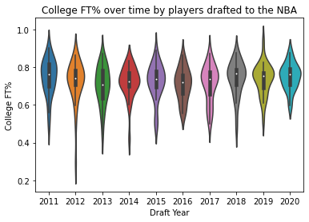

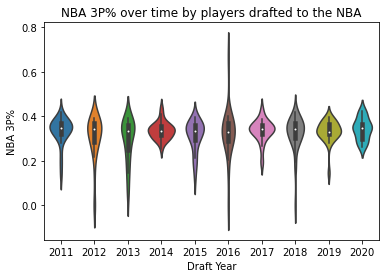

```python
#create a violin plot to for our college FT percentage
fig, ax = plt.subplots()
sb.violinplot(x = 'DraftYear',y='college_FT%', data=total_data, bw =.5)
ax.set_xlabel("Draft Year")
ax.set_ylabel("College FT%")
ax.set_title("College FT% over time by players drafted to the NBA")
text = fig.text(0.5, 1.0, 'College FT% over time by players drafted to the NBA')
text.remove()

#create a violin plot to for our NBA 3 point percentage
fig, ax = plt.subplots()
sb.violinplot(x = 'DraftYear',y='nba_3P%', data=total_data, bw =.5)
ax.set_xlabel("Draft Year")
ax.set_ylabel("NBA 3P%")
ax.set_title("NBA 3P% over time by players drafted to the NBA")
text = fig.text(0.5, 1.0, 'College FT% over time by players drafted to the NBA')
text.remove()
```

# Linear Regression on College Free Throw Percentage and NBA Three Point Percentage

The method for performing a linear regression in python is rather simple. For most of it we can use imported libraries to automate the process for us. In the below examples of linear regression you can see we first pick two variables to perform our regression on. Then we use a function called train_test_split to break up our data into testing groups and training groups. After that we create a linear regression object and then fit this object to our two variables we are using. After that we can use .coef to find the coefficient of the regression line and print it out.

The next step is visualizing this data into a graph. To do this quickly and easily we used the Seaborn library and imported it as sb. The .regplot function in the library allows us to simply add the two variables we want to use to make our graph and our graph will be outputted. Then, all that's left is the task of adding a title and we're ready to go. This technique for computing the coefficient of linear regression and then creating a visualization of the regression is used repeatedly throughout the tutorial.

The below linear regression between college free throw percentage and NBA three-point percentage outputs a coefficient of 0.35917025 which denotes a positive correlation between the two variables. The dataset modeled a line of best fit that indicates that the higher the free throw percentage is for a player in college, the higher the three-point percentage is for them in the NBA. This may seem like we have already answered our question, free throw shooting in college does correlate to NBA three point success. However, we should still consider other variables to see if free throw percentage is a better indicator than others. If it is not better than our other variables then we are looking in the wrong place to find the best indicator for NBA three point shooting success.

```
Linear Regression Coefficient from training on college FT percentage and NBA 3 point percentage: [[0.35917025]]
```

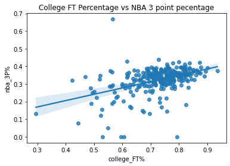

```python
#linear regression for college FT% and nba 3 point percentage
X = np.array(total_data['college_FT%']).reshape(-1, 1)
Y = np.array(total_data['nba_3P%']).reshape(-1, 1)
#splitting our data into a training set and a testing set
x_train, x_test, y_train, y_test = train_test_split(X, Y, test_size = 0.25)
lin_regr = LinearRegression()
lin_regr.fit(X, Y)
regr_coef_FTv3P = lin_regr.coef_
print("Linear Regression Coefficient from training on college FT percentage and NBA 3 point percentage: " + str(regr_coef_FTv3P))
#plotting our data and the regression line
y_pred = lin_regr.predict(x_test)
sb.regplot(x = total_data['college_FT%'], y = total_data['nba_3P%'])
plt.title("College FT Percentage vs NBA 3 point pecentage")
plt.show()
```

# Linear Regression on College Field Goal Percentage and NBA Three Point Percentage

We now check other college shooting statistics to find if college free throw shooting percentage is really the best indicator for NBA three point percentage. The below linear regression is between field goal percentages in college versus NBA three-point percentages. The model outputs a negative coefficient of -0.33893196 which denotes a negative relationship between the independent and dependent variable: the higher field goal percentage in college predicts a lower three-pointer percentage for a player in the NBA.

At face value this result may come off as surprising, shouldn't a better shooter from everywhere also shoot better from three? But when we really think about what the data is telling us the answer arrives. Players with high shooting percentages are often centers and forwards who take a majority of their shots very close to the basket. These close-to-the-basket shots are much easier to make than farther away which boosts centers and forwards field goal percentage. However, the trade off is most centers and forwards don't shoot or practice three point shots often and in turn their three point percentage suffers.

```
Linear Regression Coefficient from training on college FG percentage and NBA 3 point percentage: [[-0.33893196]]
```

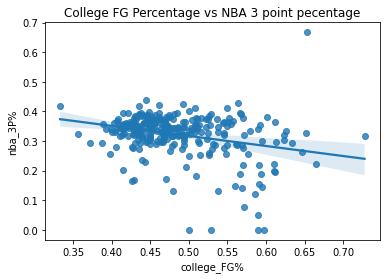

```python
#linear regression for college FG% and nba 3 point percentage
X = np.array(total_data['college_FG%']).reshape(-1, 1)
Y = np.array(total_data['nba_3P%']).reshape(-1, 1)
#splitting our data into a training set and a testing set
x_train, x_test, y_train, y_test = train_test_split(X, Y, test_size = 0.25)
lin_regr = LinearRegression()
lin_regr.fit(X, Y)
regr_coef_FGv3P = lin_regr.coef_
print("Linear Regression Coefficient from training on college FG percentage and NBA 3 point percentage: " + str(regr_coef_FGv3P))
#plotting our data and the regression line
y_pred = lin_regr.predict(x_test)
sb.regplot(x = total_data['college_FG%'], y = total_data['nba_3P%'])
plt.title("College FG Percentage vs NBA 3 point pecentage")
plt.show()
```

# Linear Regression on College Three Point Percentage and NBA Three Point Percentage

The below linear regression model represents college three-point percentages versus NBA three-point percentages. The regression outputs a positive coefficient of 0.27631343 which indicates a positive correlation. The higher the college three-point percentage is, the higher the NBA three-point percentage tends to be.

After getting all three linear regression coefficients from comparing these different stats, free throws has come out as the highest. It is particularly interesting that a good free throw percentage in college is a stronger indicator for NBA three point percentage than college three point percentage. Before performing this analysis we would never have suspected that this was the case. It would seem to be that reporters and commentators have been correct in their estimations that free throw percentage is a good and perhaps even the best indicator for NBA three point accuracy.

```
Linear Regression Coefficient from training on college 3 point percentage and NBA 3 point percentage: [[0.27631343]]
```

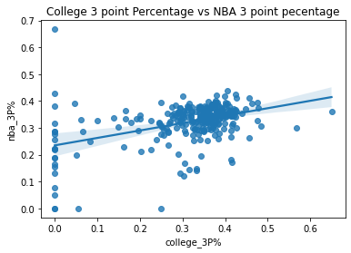

```python
#linear regression for college 3 point and nba 3 point percentage
X = np.array(total_data['college_3P%']).reshape(-1, 1)
Y = np.array(total_data['nba_3P%']).reshape(-1, 1)
#splitting our data into a training set and a testing set
x_train, x_test, y_train, y_test = train_test_split(X, Y, test_size = 0.25)
lin_regr = LinearRegression()
lin_regr.fit(X, Y)
regr_coef_3Pv3P = lin_regr.coef_
print("Linear Regression Coefficient from training on college 3 point percentage and NBA 3 point percentage: " + str(regr_coef_3Pv3P))
#plotting our data and the regression line
y_pred = lin_regr.predict(x_test)
sb.regplot(x = total_data['college_3P%'], y = total_data['nba_3P%'])
plt.title("College 3 point Percentage vs NBA 3 point pecentage")
plt.show()
```

# Finishing our Linear Regressions for other potential variables

Here we analyze the relationships between NBA field goal percentage, NBA free throw percentage and NBA three-point percentage with all three college statistics that were previously used as independent variables in our earlier regression models. In this interpretation, note that the college statistics are still used as independent variables while each NBA statistic is used as the dependent variable. After performing six more linear regressions we can create a 3x3 data frame that holds coefficients that provide indicators on which college metrics best predict our NBA metrics.

```python
#regression between college FT percentage and NBA FT percentage
X = np.array(total_data['college_FT%']).reshape(-1, 1)
Y = np.array(total_data['nba_FT%']).reshape(-1, 1)
x_train, x_test, y_train, y_test = train_test_split(X, Y, test_size = 0.25)
lin_regr = LinearRegression()
lin_regr.fit(X, Y)
regr_coef_FTvFT = lin_regr.coef_

#regression between college FG percentage and NBA FT percentage
X = np.array(total_data['college_FG%']).reshape(-1, 1)
Y = np.array(total_data['nba_FT%']).reshape(-1, 1)
x_train, x_test, y_train, y_test = train_test_split(X, Y, test_size = 0.25)
lin_regr = LinearRegression()
lin_regr.fit(X, Y)
regr_coef_FGvFT = lin_regr.coef_

#regression between college 3P percentage and NBA FT percentage
X = np.array(total_data['college_3P%']).reshape(-1, 1)
Y = np.array(total_data['nba_FT%']).reshape(-1, 1)
x_train, x_test, y_train, y_test = train_test_split(X, Y, test_size = 0.25)
lin_regr = LinearRegression()
lin_regr.fit(X, Y)
regr_coef_3PvFT = lin_regr.coef_

#regression between college FT percentage and NBA FG percentage
X = np.array(total_data['college_FT%']).reshape(-1, 1)
Y = np.array(total_data['nba_FG%']).reshape(-1, 1)
x_train, x_test, y_train, y_test = train_test_split(X, Y, test_size = 0.25)
lin_regr = LinearRegression()
lin_regr.fit(X, Y)
regr_coef_FTvFG = lin_regr.coef_

#regression between college FG percentage and NBA FG percentage
X = np.array(total_data['college_FG%']).reshape(-1, 1)
Y = np.array(total_data['nba_FG%']).reshape(-1, 1)
x_train, x_test, y_train, y_test = train_test_split(X, Y, test_size = 0.25)
lin_regr = LinearRegression()
lin_regr.fit(X, Y)
regr_coef_FGvFG = lin_regr.coef_

#regression between college 3P percentage and NBA FG percentage
X = np.array(total_data['college_3P%']).reshape(-1, 1)
Y = np.array(total_data['nba_FG%']).reshape(-1, 1)
x_train, x_test, y_train, y_test = train_test_split(X, Y, test_size = 0.25)
lin_regr = LinearRegression()
lin_regr.fit(X, Y)
regr_coef_3PvFG = lin_regr.coef_

#Create a heat map that shows our correlation coefficents in an easy to read manner
idx = ['College FG%', 'College FT%', 'College 3P%']
cols = ['NBA FG%', 'NBA FT%', 'NBA 3P%']
data_coef = [[regr_coef_FGvFG,regr_coef_FGvFT,regr_coef_FGv3P],[regr_coef_FTvFG,regr_coef_FTvFT,regr_coef_FTv3P],[regr_coef_3PvFG,regr_coef_3PvFT,regr_coef_3Pv3P]]
df = pd.DataFrame(data_coef, columns = cols, index = idx)
display(HTML(df.head(20).to_html()))
```

|  | NBA FG% | NBA FT% | NBA 3P% |
| --- | --- | --- | --- |
| College FG% | [[0.612744382507065]] | [[-0.40556317910219897]] | [[-0.33893196179935076]] |
| College FT% | [[-0.27787161795710763]] | [[0.6023011371940359]] | [[0.3591702473713717]] |
| College 3P% | [[-0.3061018770267989]] | [[0.2830292670059469]] | [[0.27631342820843147]] |

# Creating a Heat Map

To help visualize all nine regressions that we have done and their results we can create a heat map like the one below. This is accomplished using the Seaborn library like we have mentioned above and the particular method is .heatmap(). This will output a visualization of our data frame where the darker reds indicate the higher positive correlations and the lighter reds are the lower negative correlations.

From the heatmap, we can see that college field goal percentage has a positive correlation with NBA field goal percentages but negative correlations with NBA free throw and three-point percentages. Both college free throw percentages and three-point percentages have a negative correlation with NBA field goal percentages but positive correlations with NBA free throw and three-point percentages.

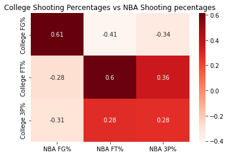

```python
df = df.astype(float)
sb.heatmap(df, annot= True, cmap="Reds")
plt.title("College Shooting Percentages vs NBA Shooting pecentages")
text = fig.text(0.5, 1.0, "College Shooting Percentages vs NBA Shooting pecentages")
text.remove()
```

# What can we conclude?

After performing our linear regressions we can conclude that college free throw percentage is the best indicator for NBA three point success. This conclusion has effects from the amatuer level all the way to the pros. Clearly the mechanics and touch involved with making a free throw translate over to three point shooting. Amateur players can work on perfecting their free throws knowing that if they do this their three point shot is likely to develop along with it. NBA scouts can be less hesitant about taking players with low college three point percentages if their free throw numbers are good. Overall, knowing exactly which metrics correlate to others can be a powerful tool for those involved in basketball.